# Ch04 Lab 4_6 Confusion Matrix

Bruce Hartman

University of St. Francis

2026-09-10 Revised 2026-10-16T08:51:22

Abstract

We sow connections between probability and statistics studies

# Introduction

We follow Chapter 4: Classification Lab, the same as the textbook Reference 1. We use a confusion matrix to examine results of classification into two categories. We will also use these methods to analyze the Caravan data set.

# Research Question

The first dataset is stock market data and the question is whether the previous 5 days (lags) can predict the percent gain today.

What can we learn from a confusion matrix presentation of classification results?

# Packages

We load the required packages. To do KNN Analysis we need the `FNN` package. Confusion matrices are frequently made with the `caret` package, though `tidymodels` methods are equally good, and preferred. we show the old ones because they are common in literature.

```r
library(MASS) # lda
library(FNN) # knn
library(caret) # confusion matrix
library(ISLR2) #package contains the data files
library(mbadtools, quietly=TRUE) # tools for mbad courses
# resolve function conflicts
```

# Smarket Data

The stock market data `Smarket` is in the `ISLR2` package.

```r
data(Smarket)
Smarket %>% skim
```

```
── Data Summary ────────────────────────
                           Values
Name                       Piped data
Number of rows             1250
Number of columns          9
_______________________
Column type frequency:
  factor                   1
  numeric                  8
________________________
Group variables            None
```

|  | skim_variable | n_missing | complete_rate | ordered | n_unique | top_counts |
| --- | --- | --- | --- | --- | --- | --- |
| 1 | Direction | 0 | 1 | FALSE | 2 | Up: 648, Dow: 602 |

|  | skim_variable | n_missing | complete_rate | mean | sd | p0 | p25 | p50 | p75 | p100 | hist |
| --- | --- | --- | --- | --- | --- | --- | --- | --- | --- | --- | --- |
| 1 | Year | 0 | 1 | 2003.0160000 | 1.4090182 | 2001.00000 | 2002.0000 | 2003.00000 | 2004.000000 | 2005.00000 | ▇▇▇▇▇ |
| 2 | Lag1 | 0 | 1 | 0.0038344 | 1.1362988 | -4.92200 | -0.6395 | 0.03900 | 0.596750 | 5.73300 | ▁▃▇▁▁ |
| 3 | Lag2 | 0 | 1 | 0.0039192 | 1.1362803 | -4.92200 | -0.6395 | 0.03900 | 0.596750 | 5.73300 | ▁▃▇▁▁ |
| 4 | Lag3 | 0 | 1 | 0.0017160 | 1.1387030 | -4.92200 | -0.6400 | 0.03850 | 0.596750 | 5.73300 | ▁▃▇▁▁ |
| 5 | Lag4 | 0 | 1 | 0.0016360 | 1.1387737 | -4.92200 | -0.6400 | 0.03850 | 0.596750 | 5.73300 | ▁▃▇▁▁ |
| 6 | Lag5 | 0 | 1 | 0.0056096 | 1.1475502 | -4.92200 | -0.6400 | 0.03850 | 0.597000 | 5.73300 | ▁▃▇▁▁ |
| 7 | Volume | 0 | 1 | 1.4783050 | 0.3603571 | 0.35607 | 1.2574 | 1.42295 | 1.641675 | 3.15247 | ▁▇▅▁▁ |
| 8 | Today | 0 | 1 | 0.0031384 | 1.1363341 | -4.92200 | -0.6395 | 0.03850 | 0.596750 | 5.73300 | ▁▃▇▁▁ |

# Research Problem

# Validation Procedure

Our validation Problem: predict year 2005 using years before that.

Let’s see how to use a training dataset to train the logistic regression, and then test it on a test dataset. We create a training set to evaluate the classification.

This is a `tidymodels` workflow way to do it. The percentage is chosen to give the same proportions as in the original example.

```r
split <- initial_time_split(Smarket, prop = .799)
train_data <- training(split)
test_data  <- testing(split)
dim(train_data)
```

```
[1] 998   9
```

```r
dim(test_data)
```

```
[1] 252   9
```

```r
Smarket.2005 = test_data
```

There are 252 observations in the 2005 test data. We will create a new vector to hold the target variable for the 2005 period. These are the outcomes we actually observed in 2005. Our prediction should come close to these.

```r
Direction.2005= test_data$Direction
dim(Smarket.2005)
```

```
[1] 252   9
```

# Logistic Regression Model

As on p 174 (160) we will use logistic regression to fit the best two lags (lowest p-values) on the training subset.

```r
glm.fit2 = glm(Direction~Lag1+Lag2,
               data=train_data, family ="binomial")
glm.probs2 = predict (glm.fit2 , Smarket.2005 , type="response")
```

What fraction should we use for Direction=Up? The prior probability of Up in the dataset is:

```r
prior = sum((Smarket$Direction == "Up")*1) / nrow(Smarket)
prior
```

```
[1] 0.5184
```

We will use `prior` for the prior probability of “Up”. A *positive* direction is taken to be “Up”.

```r
glm.pred2 = case_when( glm.probs2 > prior ~ "Up",
                       .default = "Down") %>%
  as.factor

t2 = data.frame(Direction=Direction.2005, .pred = glm.pred2) %>%
  conf_mat(Direction, .pred)
t2
```

```
          Truth
Prediction Down  Up
      Down   94 117
      Up     17  24
```

```r
t2 %>% summary(event_level="second")
```

| .metric | .estimator | .estimate |
| --- | --- | --- |
| accuracy | binary | 0.46825397 |
| kap | binary | 0.01556761 |
| sens | binary | 0.17021277 |
| spec | binary | 0.84684685 |
| ppv | binary | 0.58536585 |
| npv | binary | 0.44549763 |
| mcc | binary | 0.02294600 |
| j_index | binary | 0.01705961 |
| bal_accuracy | binary | 0.50852981 |
| detection_prevalence | binary | 0.16269841 |

[output cut: 3 more lines]

# Confusion Matrix

The `caret` package has a useful confusion matrix function. Its argument is the contingency table `t2$table` produced above.

Report the `caret` confusion matrix stats for the previous logistic regression with 2 lags.

```r
caret::confusionMatrix(t2$table, positive="Up") %>%
    tidy() %>%
    gt_add_significance()
```

| term | class | estimate | conf.low | conf.high | p.value |
| --- | --- | --- | --- | --- | --- |
| accuracy | NA | 0.4683 | 0.4054 | 0.5319 | 0.9985 |
| kappa | NA | 0.0156 | NA | NA | NA |
| mcnemar | NA | NA | NA | NA | 0.0000 |
| sensitivity | Up | 0.1702 | NA | NA | NA |
| specificity | Up | 0.8468 | NA | NA | NA |
| pos_pred_value | Up | 0.5854 | NA | NA | NA |
| neg_pred_value | Up | 0.4455 | NA | NA | NA |
| precision | Up | 0.5854 | NA | NA | NA |
| recall | Up | 0.1702 | NA | NA | NA |
| f1 | Up | 0.2637 | NA | NA | NA |
| prevalence | Up | 0.5595 | NA | NA | NA |
| detection_rate | Up | 0.0952 | NA | NA | NA |
| detection_prevalence | Up | 0.1627 | NA | NA | NA |
| balanced_accuracy | Up | 0.5085 | NA | NA | NA |

There is a lot more information here.

# Accuracy vs Balanced Accuracy

This article explains why balanced_accuracy might be a better measure than accuracy.

# Caravan Dataset

```r
data(Caravan)
Caravan %>% skim
```

```
── Data Summary ────────────────────────
                           Values
Name                       Piped data
Number of rows             5822
Number of columns          86
_______________________
Column type frequency:
  factor                   1
  numeric                  85
________________________
Group variables            None
```

|  | skim_variable | n_missing | complete_rate | ordered | n_unique | top_counts |
| --- | --- | --- | --- | --- | --- | --- |
| 1 | Purchase | 0 | 1 | FALSE | 2 | No: 5474, Yes: 348 |

|  | skim_variable | n_missing | complete_rate | mean | sd | p0 | p25 | p50 | p75 | p100 | hist |
| --- | --- | --- | --- | --- | --- | --- | --- | --- | --- | --- | --- |
| 1 | MOSTYPE | 0 | 1 | 2.425335e+01 | 12.84670570 | 1 | 10 | 30 | 35 | 41 | ▆▃▃▇▇ |
| 2 | MAANTHUI | 0 | 1 | 1.110615e+00 | 0.40584207 | 1 | 1 | 1 | 1 | 10 | ▇▁▁▁▁ |
| 3 | MGEMOMV | 0 | 1 | 2.678805e+00 | 0.78983454 | 1 | 2 | 3 | 3 | 5 | ▁▆▇▂▁ |
| 4 | MGEMLEEF | 0 | 1 | 2.991240e+00 | 0.81458881 | 1 | 2 | 3 | 3 | 6 | ▅▇▃▁▁ |
| 5 | MOSHOOFD | 0 | 1 | 5.773617e+00 | 2.85675983 | 1 | 3 | 7 | 8 | 10 | ▃▃▃▇▃ |
| 6 | MGODRK | 0 | 1 | 6.964960e-01 | 1.00323378 | 0 | 0 | 0 | 1 | 9 | ▇▂▁▁▁ |
| 7 | MGODPR | 0 | 1 | 4.626932e+00 | 1.71584254 | 0 | 4 | 5 | 6 | 9 | ▁▂▇▃▁ |
| 8 | MGODOV | 0 | 1 | 1.069907e+00 | 1.01750254 | 0 | 0 | 1 | 2 | 5 | ▇▃▁▁▁ |
| 9 | MGODGE | 0 | 1 | 3.258502e+00 | 1.59764655 | 0 | 2 | 3 | 4 | 9 | ▂▇▇▁▁ |
| 10 | MRELGE | 0 | 1 | 6.183442e+00 | 1.90948247 | 0 | 5 | 6 | 7 | 9 | ▁▁▃▇▃ |

[output cut: 75 more lines]

```r
# fraction of Purchase Yes/ all Purchase
Caravan %>% group_by(Purchase) %>%
  summarize(count=n(),
            fraction = count/nrow(Caravan))
```

| Purchase | count | fraction |
| --- | --- | --- |
| No | 5474 | 0.94022673 |
| Yes | 348 | 0.05977327 |

There are 5822 observations of 86 features. Purchases “Yes” are 5.98% of total observations.

# Standardized Data

According to p 179 in Reference 1 we have to standardize the drivers, since KNN is subject to scale effects. We do so, and then we create a test dataset of the first 1000 items, using the balance of the dataset, 4822 observations, for training. We use the function `scale` to compute z-scores (standardized values) of the drivers.

```r
standardized.X=scale(Caravan[,-86]) #col 86 is the target
# skim the result
standardized.X %>% skim()
```

```
── Data Summary ────────────────────────
                           Values
Name                       Piped data
Number of rows             5822
Number of columns          85
_______________________
Column type frequency:
  numeric                  85
________________________
Group variables            None
```

|  | skim_variable | n_missing | complete_rate | mean | sd | p0 | p25 | p50 | p75 | p100 | hist |
| --- | --- | --- | --- | --- | --- | --- | --- | --- | --- | --- | --- |
| 1 | MOSTYPE | 0 | 1 | -7.025576e-17 | 1 | -1.81006321 | -1.10949450 | 0.44732484 | 0.83652968 | 1.303575 | ▅▂▂▂▇ |
| 2 | MAANTHUI | 0 | 1 | -1.470838e-16 | 1 | -0.27255654 | -0.27255654 | -0.27255654 | -0.27255654 | 21.903558 | ▇▁▁▁▁ |
| 3 | MGEMOMV | 0 | 1 | -1.780112e-16 | 1 | -2.12551421 | -0.85942625 | 0.40666171 | 0.40666171 | 2.938838 | ▁▆▇▂▁ |
| 4 | MGEMLEEF | 0 | 1 | 2.042807e-16 | 1 | -2.44447272 | -1.21685949 | 0.01075374 | 0.01075374 | 3.693593 | ▅▇▃▁▁ |
| 5 | MOSHOOFD | 0 | 1 | -1.458567e-17 | 1 | -1.67099007 | -0.97089622 | 0.42929149 | 0.77933842 | 1.479432 | ▃▃▃▇▃ |
| 6 | MGODRK | 0 | 1 | -4.679016e-17 | 1 | -0.69425100 | -0.69425100 | -0.69425100 | 0.30252565 | 8.276739 | ▇▂▁▁▁ |
| 7 | MGODPR | 0 | 1 | 7.076517e-17 | 1 | -2.69659495 | -0.36537871 | 0.21742536 | 0.80022942 | 2.548642 | ▁▂▇▃▁ |
| 8 | MGODOV | 0 | 1 | 1.075960e-17 | 1 | -1.05150327 | -1.05150327 | -0.06870474 | 0.91409379 | 3.862489 | ▇▃▁▁▁ |
| 9 | MGODGE | 0 | 1 | 9.044304e-17 | 1 | -2.03956390 | -0.78772256 | -0.16180189 | 0.46411878 | 3.593722 | ▂▇▇▁▁ |
| 10 | MRELGE | 0 | 1 | -1.352488e-16 | 1 | -3.23828168 | -0.61977113 | -0.09606902 | 0.42763309 | 1.475037 | ▁▁▃▇▃ |

[output cut: 75 more lines]

There are 5822 standardized observations, and 85 drivers.

# Validation

We need to test the data on part of the dataset and train it on the rest. We choose 1000 beginning records to test on, and the remainder 4822 to train on. It’s close to an 80-20 rule often followed for selecting training and test data.

The version of KNN that we’re using requires separate objects for the drives and for the target.

```r
# make a vector with the first 1000 row numbers
test=as.vector(1:1000)
# build the test dataset for the drivers by selecting those rows
test.X=standardized.X[test,]
# bui8ld a training dataset with the rows not in test
train.X=standardized.X[-test,] #this works
# similarly set up the train and test target vectors of Purchase
train.Y=Caravan$Purchase[-test]
test.Y=Caravan$Purchase[test]
```

# KNN Model

Run the `FNN::knn` model. Our supervision is limited to picking the number of nearest neighbors to consider. We begin with $k=1$, and we set a seed so that the code can be reproduced. The function produces the predicted classes of the Y variable.

```r
set.seed(1)
knn.predc = FNN::knn(train.X, test.X, train.Y,k=1)
CM1 = data.frame(Purchase = test.Y,
                 .pred = factor(knn.predc) ) %>%
  conf_mat(Purchase, .pred)
CM1
```

```
          Truth
Prediction  No Yes
       No  874  50
       Yes  67   9
```

```r
CM1 %>% summary(event_level = "second")
```

| .metric | .estimator | .estimate |
| --- | --- | --- |
| accuracy | binary | 0.88300000 |
| kap | binary | 0.07166434 |
| sens | binary | 0.15254237 |
| spec | binary | 0.92879915 |
| ppv | binary | 0.11842105 |
| npv | binary | 0.94588745 |
| mcc | binary | 0.07232532 |
| j_index | binary | 0.08134152 |
| bal_accuracy | binary | 0.54067076 |
| detection_prevalence | binary | 0.07600000 |

[output cut: 3 more lines]

Now try 3 nearest neighbors.

```r
knn.predc3=knn(train.X, test.X, train.Y,k=3)
CM3 = data.frame(Purchase=test.Y,
           .pred = factor(knn.predc3)) %>%
  conf_mat(Purchase, .pred)
CM3
```

```
          Truth
Prediction  No Yes
       No  920  54
       Yes  21   5
```

```r
CM3 %>% summary(event_level = "second")
```

| .metric | .estimator | .estimate |
| --- | --- | --- |
| accuracy | binary | 0.92500000 |
| kap | binary | 0.08460675 |
| sens | binary | 0.08474576 |
| spec | binary | 0.97768332 |
| ppv | binary | 0.19230769 |
| npv | binary | 0.94455852 |
| mcc | binary | 0.09243609 |
| j_index | binary | 0.06242908 |
| bal_accuracy | binary | 0.53121454 |
| detection_prevalence | binary | 0.02600000 |

[output cut: 3 more lines]

The `accuracy` is .925 but `balanced_accuracy` is down to .53. It is being buoyed up by the large number of “No” cases. `detection_prevalence`, the positive state, is .026.

Now try 5.

```r
knn.predc5=knn(train.X,test.X,train.Y, k=5)
CM5 = data.frame(Purchase=test.Y,
           .pred = factor(knn.predc5)) %>%
  conf_mat(Purchase, .pred)
CM5
```

```
          Truth
Prediction  No Yes
       No  931  55
       Yes  10   4
```

```r
CM5 %>% summary(event_level = "second")
```

| .metric | .estimator | .estimate |
| --- | --- | --- |
| accuracy | binary | 0.93500000 |
| kap | binary | 0.08897236 |
| sens | binary | 0.06779661 |
| spec | binary | 0.98937301 |
| ppv | binary | 0.28571429 |
| npv | binary | 0.94421907 |
| mcc | binary | 0.11465253 |
| j_index | binary | 0.05716962 |
| bal_accuracy | binary | 0.52858481 |
| detection_prevalence | binary | 0.01400000 |

[output cut: 3 more lines]

We will have to live with the fact that we are often wrong when we predict “Yes”.

# Logistic Model

Fit a logistic model, p181. First construct the standardized dataframe.

```r
df_train = data.frame(train.X, Purchase = train.Y)
df_test = data.frame(test.X, Purchase = test.Y)
```

```r
glm.fit = glm(Purchase ~ .,
              data=df_train,
              family=binomial)
glm.probs = predict(glm.fit, df_test, type="response")
dim(glm.probs)
```

We use a prior probability of `prior` for tossing a fair coin.

```r
glm.pred = case_when(glm.probs > prior ~ "Yes",
                     .default = "No")
T50 = data.frame(Purchase = test.Y,
                 .pred = factor(glm.pred)) %>%
  conf_mat(Purchase, .pred)
T50
```

```
          Truth
Prediction  No Yes
       No  935  59
       Yes   6   0
```

```r
T50 %>% summary(event_level = "second")
```

| .metric | .estimator | .estimate |
| --- | --- | --- |
| accuracy | binary | 0.935000000 |
| kap | binary | -0.011012257 |
| sens | binary | 0.000000000 |
| spec | binary | 0.993623804 |
| ppv | binary | 0.000000000 |
| npv | binary | 0.940643863 |
| mcc | binary | -0.019454211 |
| j_index | binary | -0.006376196 |
| bal_accuracy | binary | 0.496811902 |
| detection_prevalence | binary | 0.006000000 |

[output cut: 3 more lines]

`accuracy` 0.935 when it predicts “No” but detection_prevalence is .006 when it predicts “Yes”. Since we want it to predict Yes when it’s appropriate, this is not good.

# Visualizing a Confusion Matrix

Here is a built-in R function to make a visualization of a confusion matrix. I don’t think it is very helpful.

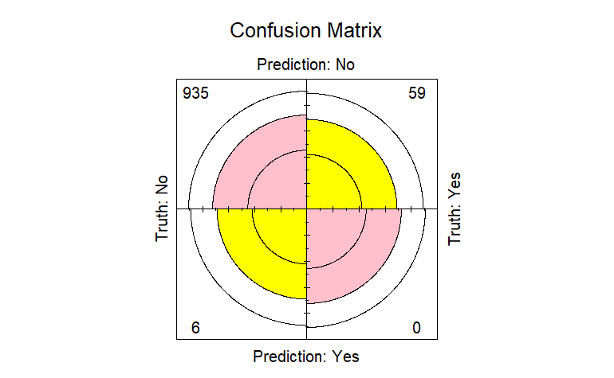

```r
cf = T50$table # from the last example.
fourfoldplot(cf,color=c("yellow","pink"),
             main = "Confusion Matrix")
```

You can make a better plot with `ggplot`.

```r
# get the data set up
confusion_matrix=as.data.frame(T50$table)
confusion_matrix
```

| Prediction | Truth | Freq |
| --- | --- | --- |
| No | No | 935 |
| Yes | No | 6 |
| No | Yes | 59 |
| Yes | Yes | 0 |

Now plot it with `ggplot()`.

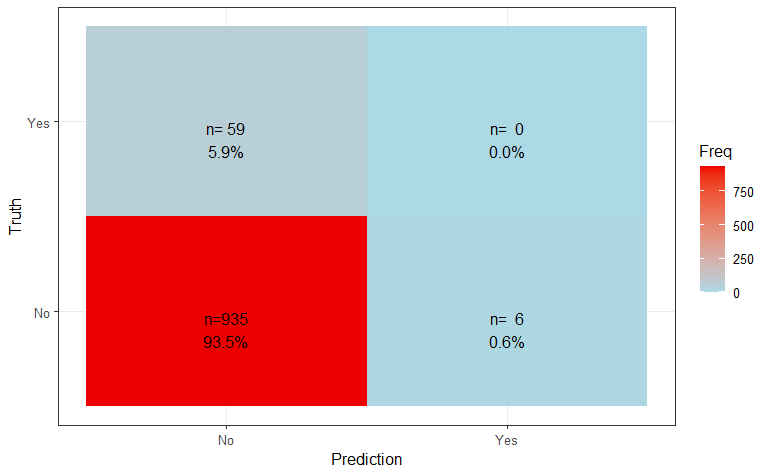

```r
ggplot(data = as.data.frame(confusion_matrix),
       mapping = aes(x = Prediction,
                     y = Truth )) +
  geom_tile(aes(fill = Freq)) +
  geom_text(aes(label = sprintf("n=%3.0f\n%3.1f%s",
                Freq, 100*Freq/sum(Freq), "%")),
            vjust = 1) +
  scale_fill_gradient(low = "lightblue",
                      high = "red2",
                      ) +
  theme_bw()
```

You might like this one better, since the colors tell you the ‘hot’ sections of the quadrangle.

# Conclusion

# References

1. ISLR (2013) Chapter 4: Classification Section 4.6, pages 154-167.
2. Brodersen, Kay H., Cheng Soon Ong, Klaas E. Stephan, and Joachim M. Buhmann. 2010. “The balanced accuracy and its posterior distribution.” [<DOI: 10.1109/ICPR.2010.764>](http://mvpa.blogspot.com/2015/12/balanced-accuracy-what-and-why.html)
3. [GeeksforGeeks](https://www.geeksforgeeks.org/visualize-confusion-matrix-using-caret-package-in-r/) www.geeksforgeeks.org (2023) Visualize Confusion Matrix Using Caret Package in R Last Updated : 19 Dec, 2023. (https://www.geeksforgeeks.org/visualize-confusion-matrix-using-caret-package-in-r/)